# PD2 - NSE

Jadwiga Słowik

November 20, 2019

## Aim

The aim of this task was to implement wrapper functions using *NSE* (*Non standard evaluation*) and then test them in order to measure their performance.

## Implemented functions

Four versions of wrapper-functions were implemented. In some of them I used the *base* package for *NSE* and in the other *rlang* package was used, which provides *quasiquotation*.

The implementation of aforementioned *NSE* functions are provided in a separate file - `nse_funs.R`.

## Tests

Tests were splitted into two groups: small and big.

### Small tests

#### min

The test case has the following form:

```r
data <- list(a=c(1,2,3), b=c(1,2,3) * 10)
fun <- min
nse1 <- my_NSE1(fun)
nse2 <- my_NSE2(fun)
nse3 <- my_NSE3(fun)
nse4 <- my_NSE4(fun)
```

To check the result:

```r
c(nse1(data, b), nse2(data, b), nse3(data, b), nse4(data, b), min(data$b))
```

```
## [1] 10 10 10 10 10
```

The benchmark is the following:

```r
visualize(
  microbenchmark::microbenchmark(
    nse1={nse1(data, b)},
    nse2={nse2(data, b)},
    nse3={nse3(data, b)},
    nse4={nse4(data, b)},
    raw={min(data$b)},
    unit="ms",
    times=10
  )
)
```

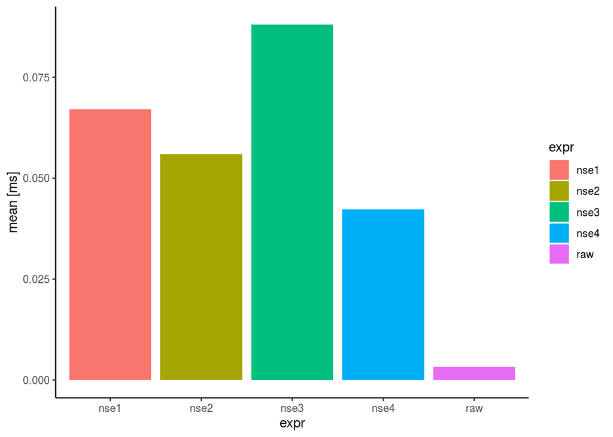

#### max

The test case has the following form:

```r
data <- list(a=c(1,2,3), b=c(1,2,3) * 10)
fun <- max
nse1 <- my_NSE1(fun)
nse2 <- my_NSE2(fun)
nse3 <- my_NSE3(fun)
nse4 <- my_NSE4(fun)
```

To check the result:

```r
c(nse1(data, b), nse2(data, b), nse3(data, b), nse4(data, b), max(data$b))
```

```
## [1] 30 30 30 30 30
```

The benchmark is the following:

```r
visualize(
  microbenchmark::microbenchmark(
    nse1={nse1(data, b)},
    nse2={nse2(data, b)},
    nse3={nse3(data, b)},
    nse4={nse4(data, b)},
    raw={max(data$b)},
    unit="ms",
    times=10
  )
)
```

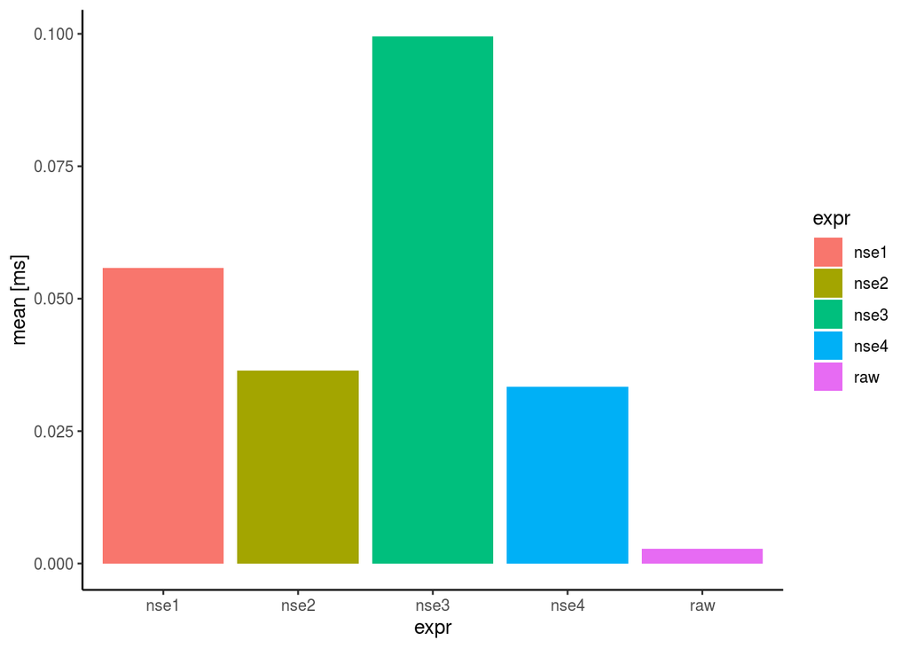

#### mean

The test case has the following form:

```r
data <- list(a=c(1,2,3), b=c(1,2,3) * 10)
fun <- mean
nse1 <- my_NSE1(fun)
nse2 <- my_NSE2(fun)
nse3 <- my_NSE3(fun)
nse4 <- my_NSE4(fun)
```

To check the result:

```r
c(nse1(data, b), nse2(data, b), nse3(data, b), nse4(data, b), mean(data$b))
```

```
## [1] 20 20 20 20 20
```

The benchmark is the following:

```r
visualize(
  microbenchmark::microbenchmark(
    nse1={nse1(data, b)},
    nse2={nse2(data, b)},
    nse3={nse3(data, b)},
    nse4={nse4(data, b)},
    raw={mean(data$b)},
    unit="ms",
    times=10
  )
)
```

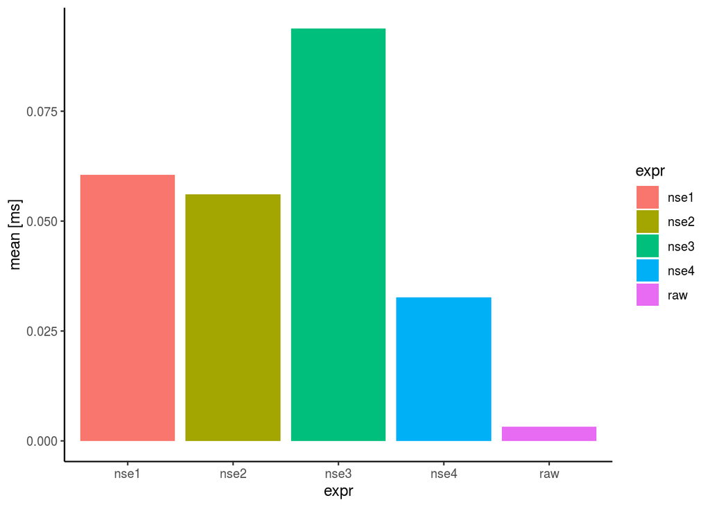

#### unlist

##### use.names=TRUE

The test case has the following form:

```r
data <- list(a=list(a=1,b=2,c=3), b=list(a=10,b=20,c=30))
fun <- unlist
nse1 <- my_NSE1(fun)
nse2 <- my_NSE2(fun)
nse3 <- my_NSE3(fun)
nse4 <- my_NSE4(fun)
```

To check the result:

```r
list(nse1(data, b, use.names=TRUE), nse2(data, b, use.names=TRUE), nse3(data, b, use.names=TRUE), nse4(data, b, use.names=TRUE), unlist(data$b, use.names=TRUE))
```

```
## [[1]]
##  a  b  c
## 10 20 30
##
## [[2]]
##  a  b  c
## 10 20 30
##
## [[3]]
##  a  b  c
## 10 20 30
##
## [[4]]
##  a  b  c
## 10 20 30
##
## [[5]]
##  a  b  c
## 10 20 30
```

The benchmark is the following:

```r
visualize(
  microbenchmark::microbenchmark(
    nse1={nse1(data, b, use.names=TRUE)},
    nse2={nse2(data, b, use.names=TRUE)},
    nse3={nse3(data, b, use.names=TRUE)},
    nse4={nse4(data, b, use.names=TRUE)},
    raw={unlist(data$b, use.names = TRUE)},
    unit="ms",
    times=10
  )
)
```

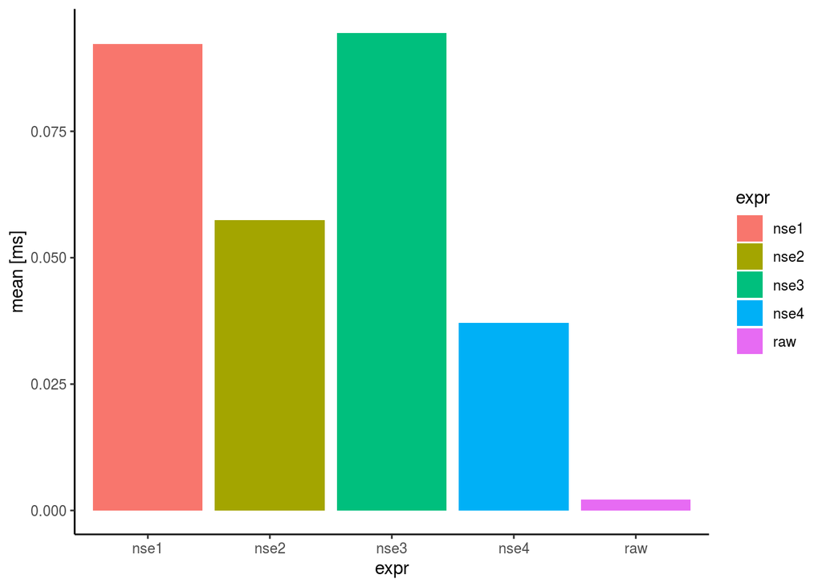

#### unlist

The test case has the following form:

```r
data <- list(a=list(a=1,b=2,c=3), b=list(a=10,b=20,c=30))
fun <- unlist
nse1 <- my_NSE1(fun)
nse2 <- my_NSE2(fun)
nse3 <- my_NSE3(fun)
nse4 <- my_NSE4(fun)
```

To check the result:

```r
list(nse1(data, b, use.names=FALSE), nse2(data, b, use.names=FALSE), nse3(data, b, use.names=FALSE), nse4(data, b, use.names=FALSE), unlist(data$b, use.names=FALSE))
```

```
## [[1]]
## [1] 10 20 30
##
## [[2]]
## [1] 10 20 30
##
## [[3]]
## [1] 10 20 30
##
## [[4]]
## [1] 10 20 30
##
## [[5]]
## [1] 10 20 30
```

The benchmark is the following:

```r
visualize(
  microbenchmark::microbenchmark(
    nse1={nse1(data, b, use.names=FALSE)},
    nse2={nse2(data, b, use.names=FALSE)},
    nse3={nse3(data, b, use.names=FALSE)},
    nse4={nse4(data, b, use.names=FALSE)},
    raw={unlist(data$b, use.names=FALSE)},
    unit="ms",
    times=10
  )
)
```

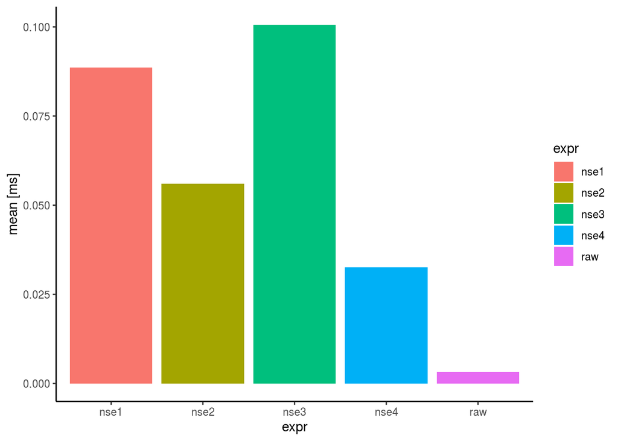

#### lm

The test case has the following form:

```r
data <- data.frame(a=1:10, b=1:10)
fun <- lm
nse1 <- my_NSE1(fun)
nse2 <- my_NSE2(fun)
nse3 <- my_NSE3(fun)
nse4 <- my_NSE4(fun)
```

To check the result:

```r
list(nse1(data, a~b)$coefficients, nse2(data, a~b)$coefficients, nse3(data, a~b)$coefficients, nse4(data, a~b)$coefficients, lm(a~b, data)$coefficients)
```

```
## [[1]]
##  (Intercept)            b
## 1.123467e-15 1.000000e+00
##
## [[2]]
##  (Intercept)            b
## 1.123467e-15 1.000000e+00
##
## [[3]]
##  (Intercept)            b
## 1.123467e-15 1.000000e+00
##
## [[4]]
##  (Intercept)            b
## 1.123467e-15 1.000000e+00
##
## [[5]]
##  (Intercept)            b
## 1.123467e-15 1.000000e+00
```

The benchmark is the following:

```r
visualize(
  microbenchmark::microbenchmark(
    nse1={nse1(data, a~b)},
    nse2={nse2(data, a~b)},
    nse3={nse3(data, a~b)},
    nse4={nse4(data, a~b)},
    raw={lm(a~b, data)},
    unit="ms",
    times=10
  )
)
```

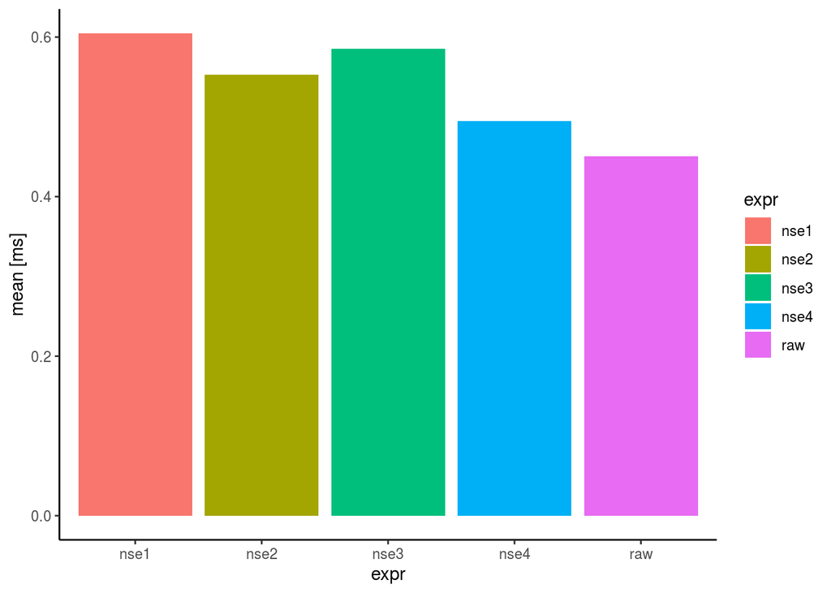

### Larger tests

Due to readablility for this kind of tests printing outputs is omitted .

### min

The test case has the following form:

```r
n <- 100000
data <- data.frame(a=1:n, b=1:n)
fun <- min
nse1 <- my_NSE1(fun)
nse2 <- my_NSE2(fun)
nse3 <- my_NSE3(fun)
nse4 <- my_NSE4(fun)
```

The benchmark is the following:

```r
visualize(
  microbenchmark::microbenchmark(
    nse1={nse1(data, a)},
    nse2={nse2(data, a)},
    nse3={nse3(data, a)},
    nse4={nse4(data, a)},
    raw={min(data$a)},
    unit="ms",
    times=10
  )
)
```

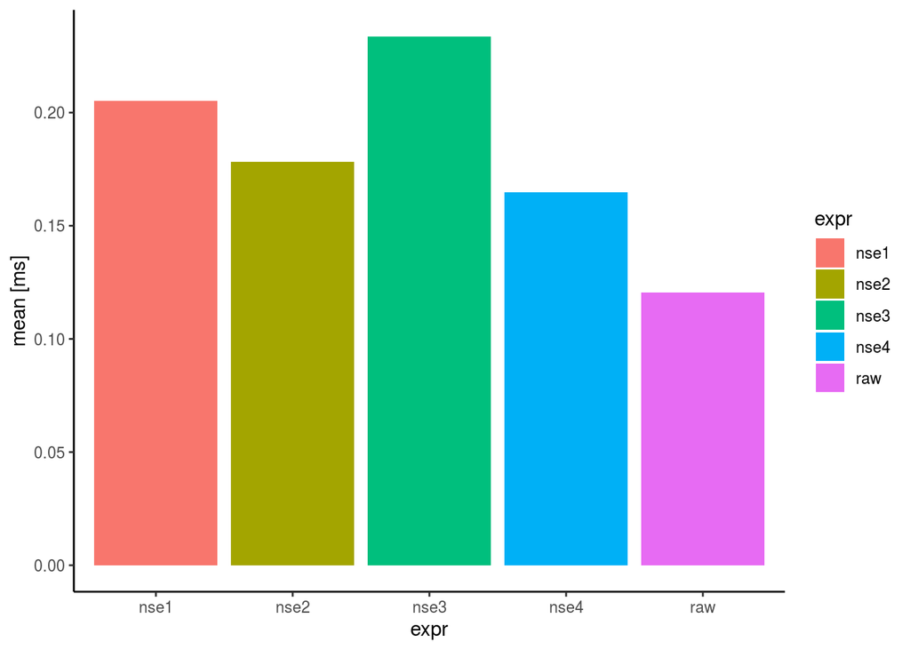

### max

The test case has the following form:

```r
n <- 100000
data <- data.frame(a=1:n, b=1:n)
fun <- max
nse1 <- my_NSE1(fun)
nse2 <- my_NSE2(fun)
nse3 <- my_NSE3(fun)
nse4 <- my_NSE4(fun)
```

The benchmark is the following:

```r
visualize(
  microbenchmark::microbenchmark(
    nse1={nse1(data, a)},
    nse2={nse2(data, a)},
    nse3={nse3(data, a)},
    nse4={nse4(data, a)},
    raw={max(data$a)},
    unit="ms",
    times=10
  )
)
```

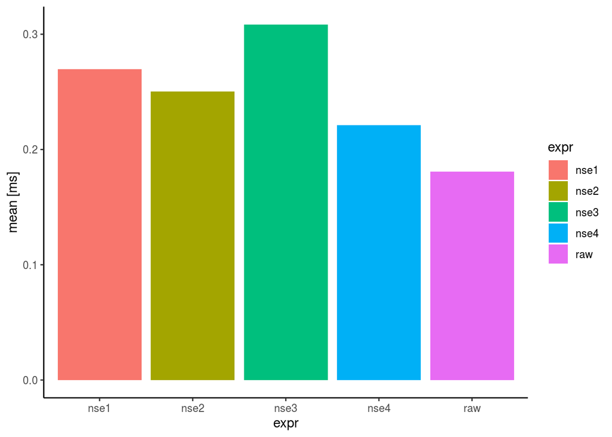

#### unlist

##### use.names=TRUE

The test case has the following form:

```r
n <- 100000
data <- data.frame(a=1:n, b=1:n)
fun <- unlist
nse1 <- my_NSE1(fun)
nse2 <- my_NSE2(fun)
nse3 <- my_NSE3(fun)
nse4 <- my_NSE4(fun)
```

The benchmark is the following:

```r
visualize(
  microbenchmark::microbenchmark(
    nse1={nse1(data, b, use.names=TRUE)},
    nse2={nse2(data, b, use.names=TRUE)},
    nse3={nse3(data, b, use.names=TRUE)},
    nse4={nse4(data, b, use.names=TRUE)},
    raw={unlist(data$b, use.names = TRUE)},
    unit="ms",
    times=10
  )
)
```

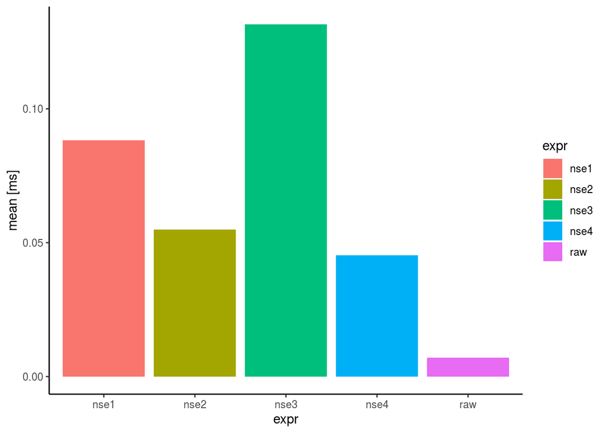

#### unlist

The test case has the following form:

```r
n <- 100000
l <- as.list(1:n)
names(l) = 1:n
data <- list(b=l)
fun <- unlist
nse1 <- my_NSE1(fun)
nse2 <- my_NSE2(fun)
nse3 <- my_NSE3(fun)
nse4 <- my_NSE4(fun)
```

The benchmark is the following:

```r
visualize(
  microbenchmark::microbenchmark(
    nse1={nse1(data, b, use.names=FALSE)},
    nse2={nse2(data, b, use.names=FALSE)},
    nse3={nse3(data, b, use.names=FALSE)},
    nse4={nse4(data, b, use.names=FALSE)},
    raw={unlist(data$b, use.names=FALSE)},
    unit="ms",
    times=10
  )
)
```

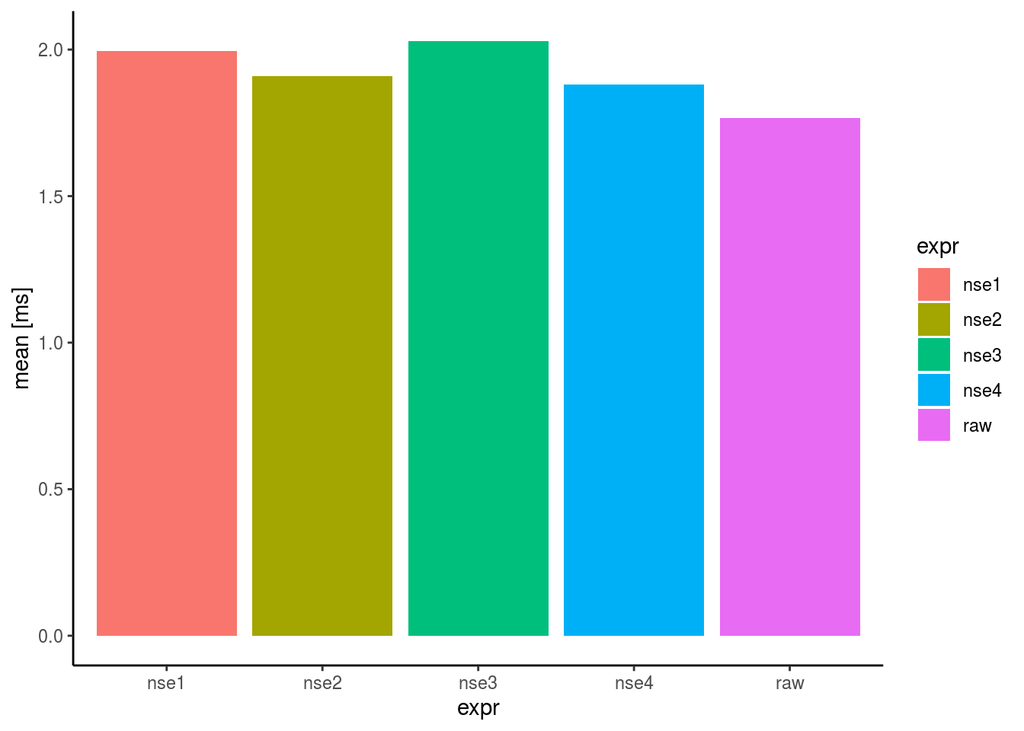

#### lm

The test case has the following form:

```r
n <- 1000000
data <- data.frame(a=1:n, b=1:n)
fun <- lm
nse1 <- my_NSE1(fun)
nse2 <- my_NSE2(fun)
nse3 <- my_NSE3(fun)
nse4 <- my_NSE4(fun)
```

The benchmark is the following:

```r
visualize(
  microbenchmark::microbenchmark(
    nse1={nse1(data, a~b)},
    nse2={nse2(data, a~b)},
    nse3={nse3(data, a~b)},
    nse4={nse4(data, a~b)},
    raw={lm(a~b, data)},
    unit="ms",
    times=10
  )
)
```

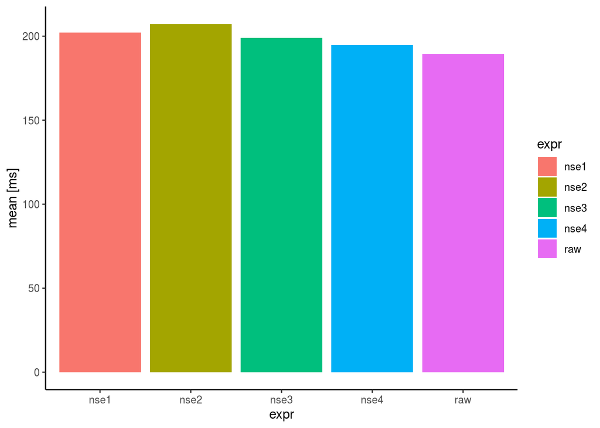